# Final-Optimal-Modeling-2

### Linear Regression

```python
# Add a constant to get an intercept
X_train_sm = sm.add_constant(X_train)
# Use the OLS function to build an Ordinary Least Square Regression Model from statsmodels.api - model is named as mymodel:
mymodel = sm.OLS(Y_train, X_train_sm, verbose = True)
mymodel_desc = mymodel.fit()
print(mymodel_desc.summary())
```

[output not shown]

[output cut: 13 more lines]

```
PRODUCT_CLASS_12_50                 4.8981      0.304     16.105      0.000       4.302       5.494
PRODUCT_CLASS_12_51                 5.9541      0.306     19.487      0.000       5.355       6.553
PRODUCT_CLASS_12_52                 2.8437      0.309      9.191      0.000       2.237       3.450
PRODUCT_CLASS_12_6                  5.8806      0.305     19.273      0.000       5.283       6.479
==============================================================================
Omnibus:                   121304.111   Durbin-Watson:                   2.000
Prob(Omnibus):                  0.000   Jarque-Bera (JB):           136030.879
Skew:                          -0.481   Prob(JB):                         0.00
Kurtosis:                       3.282   Cond. No.                     1.02e+16
==============================================================================

Warnings:
[1] Standard Errors assume that the covariance matrix of the errors is correctly specified.
[2] The smallest eigenvalue is 3.93e-19. This might indicate that there are
strong multicollinearity problems or that the design matrix is singular.
```

Linear Regression models using the stats model:

R-squared: 0.574

Adjusted R-square

The only drawback of R2 is that if new predictors (X) are added to our model, R2 only increases or remains constant but it never decreases. We can not judge that by increasing complexity of our model

Adj. R-squared: 0.574

Every individual feature verifying the features are significant or no significant

confidence depends on the co efficients and standard error.

```python
predictions = mymodel_desc.predict(sm.add_constant(X_test))
```

R2 score or accuracy score from the test data

```python
r2_score(Y_test, predictions)
```

```
0.5740996015996616
```

Printing the actual and predicted outputs

```python
pd.DataFrame({'actuals': Y_test, 'predicted':predictions}).sample(20)
```

|  | actuals | predicted |
| --- | --- | --- |
| 1189960 | 40.00 | 34.076468 |
| 1199125 | 48.00 | 47.822934 |
| 496796 | 36.80 | 30.852752 |
| 404963 | 24.50 | 42.733682 |
| 1959893 | 40.50 | 41.688837 |
| 2248276 | 22.47 | 37.833333 |
| 851759 | 56.00 | 54.778106 |
| 1271082 | 35.99 | 37.029069 |
| 3051360 | 43.86 | 40.291863 |
| 2706554 | 33.60 | 36.315070 |
| 3971139 | 29.99 | 29.600766 |
| 135072 | 25.60 | 44.628495 |
| 2975942 | 38.14 | 31.375416 |
| 1693935 | 24.00 | 32.833546 |
| 2547107 | 27.99 | 32.852222 |
| 3426967 | 41.85 | 33.433386 |
| 2092002 | 19.99 | 31.655539 |
| 4850318 | 21.75 | 32.816268 |
| 767825 | 46.00 | 50.710467 |
| 4540449 | 51.20 | 40.363158 |

Mean absolute error to predict from test data

```python
mean_absolute_error(Y_test, predictions)
```

```
6.044303785300554
```

```python
np.sqrt(mean_squared_error(Y_test, predictions))
```

```
7.686065395762976
```

```python
res = (Y_test - predictions)
```

Heteroscedasticity check

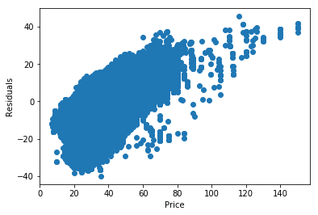

```python
plt.scatter(Y_test,res)
plt.xlabel('Price')
plt.ylabel('Residuals')
plt.show()
```

Normal distribution of errors

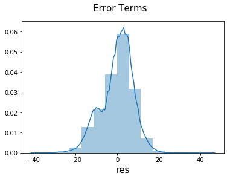

```python
fig = plt.figure()
sns.distplot(res, bins = 15)
fig.suptitle('Error Terms', fontsize = 15)                  # Plot heading
plt.xlabel('res', fontsize = 15)         # X-label
plt.show()
```